# Unsupervised Machine Learning

Joe Eckert

November 13, 2015

```r
library(HSAUR)
library(psych)
library(glmnet)
```

### Question #1: Principal Component Analysis

Load the heptathlondataset from the HSAURlibrary into your workspace. A heptathlon is a combined track and field event-based contest for women. This dataset contains scores on each event for the 1988 olympic heptathlon competition held in Seoul.

```r
hept <- heptathlon
head(hept)
```

```
##                     hurdles highjump  shot run200m longjump javelin
## Joyner-Kersee (USA)   12.69     1.86 15.80   22.56     7.27   45.66
## John (GDR)            12.85     1.80 16.23   23.65     6.71   42.56
## Behmer (GDR)          13.20     1.83 14.20   23.10     6.68   44.54
## Sablovskaite (URS)    13.61     1.80 15.23   23.92     6.25   42.78
## Choubenkova (URS)     13.51     1.74 14.76   23.93     6.32   47.46
## Schulz (GDR)          13.75     1.83 13.50   24.65     6.33   42.82
##                     run800m score
## Joyner-Kersee (USA)  128.51  7291
## John (GDR)           126.12  6897
## Behmer (GDR)         124.20  6858
## Sablovskaite (URS)   132.24  6540
## Choubenkova (URS)    127.90  6540
## Schulz (GDR)         125.79  6411
```

#### 1. Create a scatterplot matrix of all variables in the dataset. Briefly comment on the nature of the data.

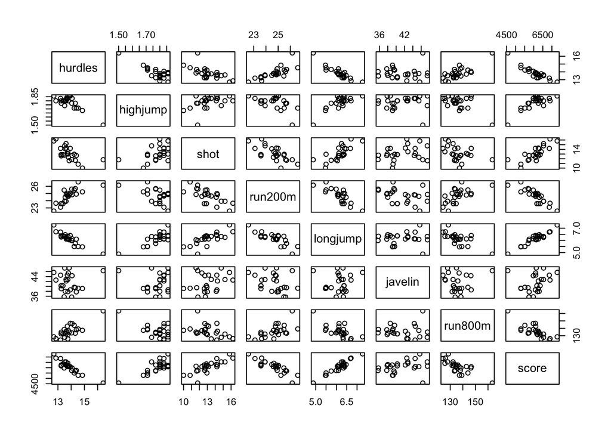

```r
plot(hept)
```

There appears to be a linear relationship between all events (except javelin and run800m) and score. Also, there appears to be some linear relationship between the hurdles event and the longjump(-), run200m(+) and shot(-). Shot also has a linear relationship with run200m(-) and longjump(+).

#### 2. It will help to have all event scores going in the “same direction” (i.e., a higher event score implies a better performance, and a lower event score implies a worse performance). To do so, transform the hurdle and running variables by subtracting the original scores for each heptathlete from the maximum score of each of those variables.

```r
hept[,'hurdles'] = max(hept[,'hurdles']) - hept[,'hurdles']
hept[,'run200m'] = max(hept[,'run200m']) - hept[,'run200m']
hept[,'run800m'] = max(hept[,'run800m']) - hept[,'run800m']
```

#### 3. Create a scatterplot matrix of all the event score variables in the “same direction.” Briefly comment on the nature of the data.

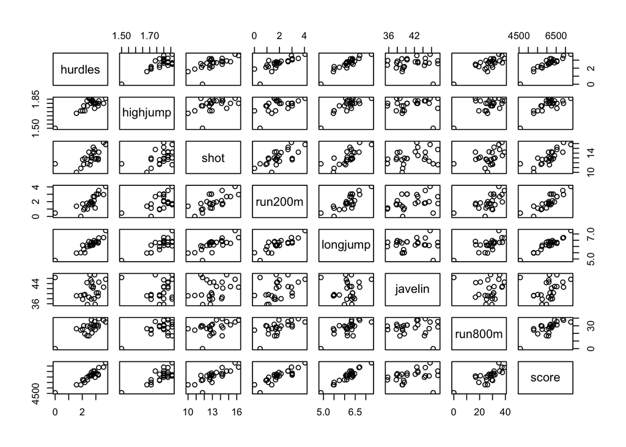

```r
plot(hept)
```

#### 4. Create a scree-plot of your newly created dataset that doesn’t include the score variable. From this plot, describe how you determine the number of principal components to extract in three different ways.

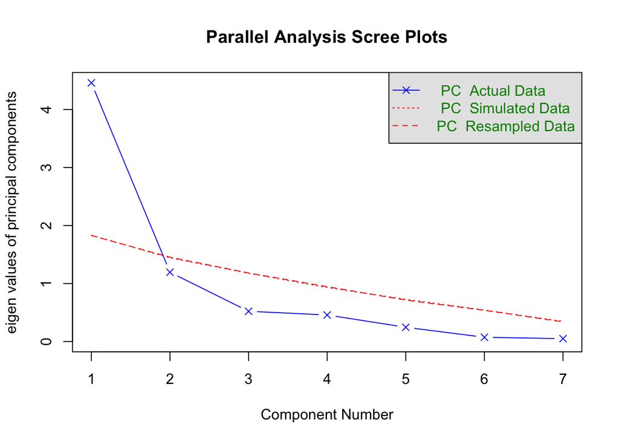

```
## Parallel analysis suggests that the number of factors =  NA  and the number of components =  1
```

```r
hept.noscr = hept[,-8]
fa.parallel(hept.noscr, fa="pc", n.iter=100)
```

Looking at the scree plots I would choose 2 principal components. There are 2 components with an eigen value greater than 1, this also happens to be the ‘elbow’ of the plot.

#### 5. Extract the appropriate number of principal components from your dataset that does not include the score variable and save this object.

```r
hept.pca = principal(hept.noscr, nfactors=2, rotate="none")
hept.pca
```

```
## Principal Components Analysis
## Call: principal(r = hept.noscr, nfactors = 2, rotate = "none")
## Standardized loadings (pattern matrix) based upon correlation matrix
##           PC1   PC2   h2    u2 com
## hurdles  0.96 -0.17 0.94 0.055 1.1
## highjump 0.80 -0.27 0.71 0.292 1.2
## shot     0.77  0.32 0.69 0.312 1.3
## run200m  0.86  0.28 0.82 0.177 1.2
## longjump 0.96 -0.06 0.93 0.068 1.0
## javelin  0.16  0.92 0.87 0.129 1.1
## run800m  0.79 -0.25 0.69 0.313 1.2
##
##                        PC1  PC2
## SS loadings           4.46 1.19
## Proportion Var        0.64 0.17
## Cumulative Var        0.64 0.81
## Proportion Explained  0.79 0.21
## Cumulative Proportion 0.79 1.00
##
## Mean item complexity =  1.2
## Test of the hypothesis that 2 components are sufficient.
##
## The root mean square of the residuals (RMSR) is  0.07
##  with the empirical chi square  5.31  with prob <  0.72
##
## Fit based upon off diagonal values = 0.99
```

#### 6. What is the variance of the each of your extracted principal components?

```r
hept.pca$loadings
```

```
##
## Loadings:
##          PC1    PC2
## hurdles   0.956 -0.173
## highjump  0.797 -0.271
## shot      0.767  0.316
## run200m   0.861  0.285
## longjump  0.964
## javelin   0.159  0.920
## run800m   0.792 -0.245
##
##                  PC1   PC2
## SS loadings    4.460 1.194
## Proportion Var 0.637 0.171
## Cumulative Var 0.637 0.808
```

The eigenvalues of the principal components (standardized variance) are 4.46 and 1.194 respectively.

#### 7. How much variability in the original dataset is captured by each of your extracted principal components?

```r
hept.pca$loadings
```

```
##
## Loadings:
##          PC1    PC2
## hurdles   0.956 -0.173
## highjump  0.797 -0.271
## shot      0.767  0.316
## run200m   0.861  0.285
## longjump  0.964
## javelin   0.159  0.920
## run800m   0.792 -0.245
##
##                  PC1   PC2
## SS loadings    4.460 1.194
## Proportion Var 0.637 0.171
## Cumulative Var 0.637 0.808
```

Principal component 1 explains 63.7% of the variance, principal component 2 explains 17.1% of the variance. Total variance accounted for by both PCs is 80.8%.

#### 8. Create a plot of the principal component loadings against each other.

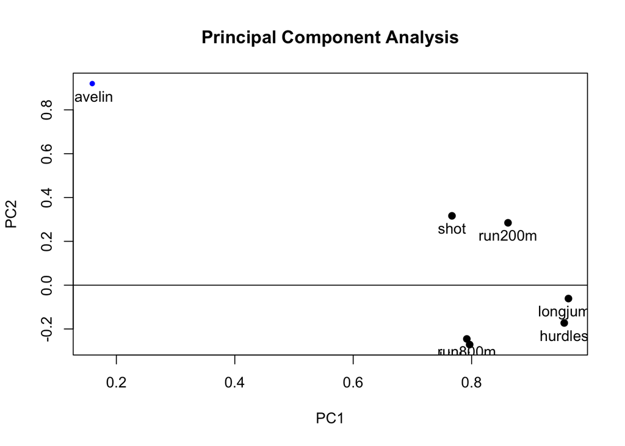

```r
factor.plot(hept.pca, labels = colnames(hept.noscr))
```

#### 9. Use the object you created in part 5 and the plot in part 8 to help construct interpretations for each principal component vector.

PC1 is composed mostly of longjump and hurdles, but all variables except javelin are included. PC2 is mainly just javelin, which makes sense given the scatterplot matrix showing a lack of relationship to the other variables.

#### 10. Create a scatterplot of each of the competitor’s results projected onto the reduced dimensions.

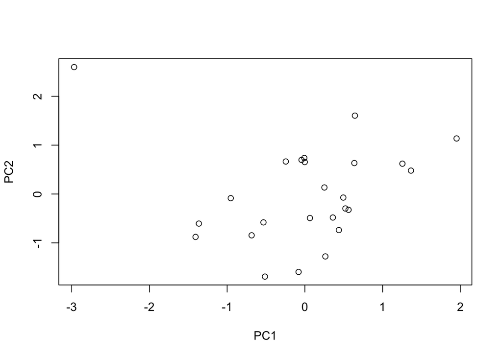

```r
plot(hept.pca$scores)
```

```r
hept.pca$scores
```

```
##                              PC1         PC2
## Joyner-Kersee (USA)  1.951501816  1.13684829
## John (GDR)           1.364712498  0.47922965
## Behmer (GDR)         1.254599251  0.62109401
## Sablovskaite (URS)   0.636075613  0.63346607
## Choubenkova (URS)    0.643497468  1.60421471
## Schulz (GDR)         0.494260857 -0.07266072
## Fleming (AUS)        0.521031629 -0.29624661
## Greiner (USA)        0.437121904 -0.73826586
## Lajbnerova (CZE)     0.251073233  0.13389024
## Bouraga (URS)        0.359773638 -0.48132480
## Wijnsma (HOL)        0.263392550 -1.27765212
## Dimitrova (BUL)      0.561784843 -0.32370952
## Scheider (SWI)      -0.007320877  0.73792674
## Braun (FRG)         -0.001787091  0.65406782
## Ruotsalainen (FIN)  -0.042968960  0.69821585
## Yuping (CHN)         0.064976125 -0.49159598
## Hagger (GB)         -0.081029266 -1.59509094
## Brown (USA)         -0.245865670  0.66520101
## Mulliner (GB)       -0.532914655 -0.58085789
## Hautenauve (BEL)    -0.514076878 -1.69028148
## Kytola (FIN)        -0.685179502 -0.84592486
## Geremias (BRA)      -0.953641249 -0.08513632
## Hui-Ing (TAI)       -1.363818863 -0.60530360
## Jeong-Mi (KOR)      -1.406348540 -0.87808138
## Launa (PNG)         -2.968849873  2.59797770
```

#### 11.Comment on any observations that appear to be outliers. Who are these competitors and why do they appear to be outliers?

```r
hept[25,]
```

```
##             hurdles highjump  shot run200m longjump javelin run800m score
## Launa (PNG)       0      1.5 11.78    0.45     4.88   46.38       0  4566
```

```r
hept[hept$score==min(hept$score),]
```

```
##             hurdles highjump  shot run200m longjump javelin run800m score
## Launa (PNG)       0      1.5 11.78    0.45     4.88   46.38       0  4566
```

### Question #2: Ridge Regression

Read in the 08prostate.txt dataset into your workspace. This dataset comes from a study by Stamey et a. (1989) of prostate cancer, measuring the correlation between the level of a prostate-specific antigen and some covariates. The included variables are the log-cancer volume, log-prostate weight, age of patient, log-amount of benign hyperplasia, seminal vesicle invasion, log-capsular penetration, Gleason score, and percent of Gleason scores 4 or 5; the response variable is the log-psa.

```r
prost <- read.table('08prostate.txt', header=TRUE)
head(prost)
```

```
##       lcavol  lweight age      lbph svi       lcp gleason pgg45       lpsa
## 1 -0.5798185 2.769459  50 -1.386294   0 -1.386294       6     0 -0.4307829
## 2 -0.9942523 3.319626  58 -1.386294   0 -1.386294       6     0 -0.1625189
## 3 -0.5108256 2.691243  74 -1.386294   0 -1.386294       7    20 -0.1625189
## 4 -1.2039728 3.282789  58 -1.386294   0 -1.386294       6     0 -0.1625189
## 5  0.7514161 3.432373  62 -1.386294   0 -1.386294       6     0  0.3715636
## 6 -1.0498221 3.228826  50 -1.386294   0 -1.386294       6     0  0.7654678
```

#### 1. Create a training set of approximately 80% of your data and a test set of approximately 20% of your data (N B: Use set.seed(0)so your results will be reproducible.)

```r
set.seed(0)
train <- sample(1:nrow(prost), 8*nrow(prost)/10)
test <- (-train)

prost.train <- prost[train, ]
prost.test <- prost[test, -9]
```

#### 2. Fit a slew of ridge regression models on your training data by checking across a wide range of lambda values. Save the coefficients of these models in an object.

```r
prost.x <- model.matrix(lpsa ~ ., prost.train)[,-1]
prost.y <- prost.train$lpsa

grid <- 10^seq(5, -2, length = 100)

prost.ridge <- glmnet(prost.x, prost.y, alpha = 0, lambda = grid)

dim(coef(prost.ridge))
```

```
## [1]   9 100
```

```r
prost.ridge.coef <- coef(prost.ridge)
```

#### 3. Plot the coefficients of these models and comment on the shrinkage.

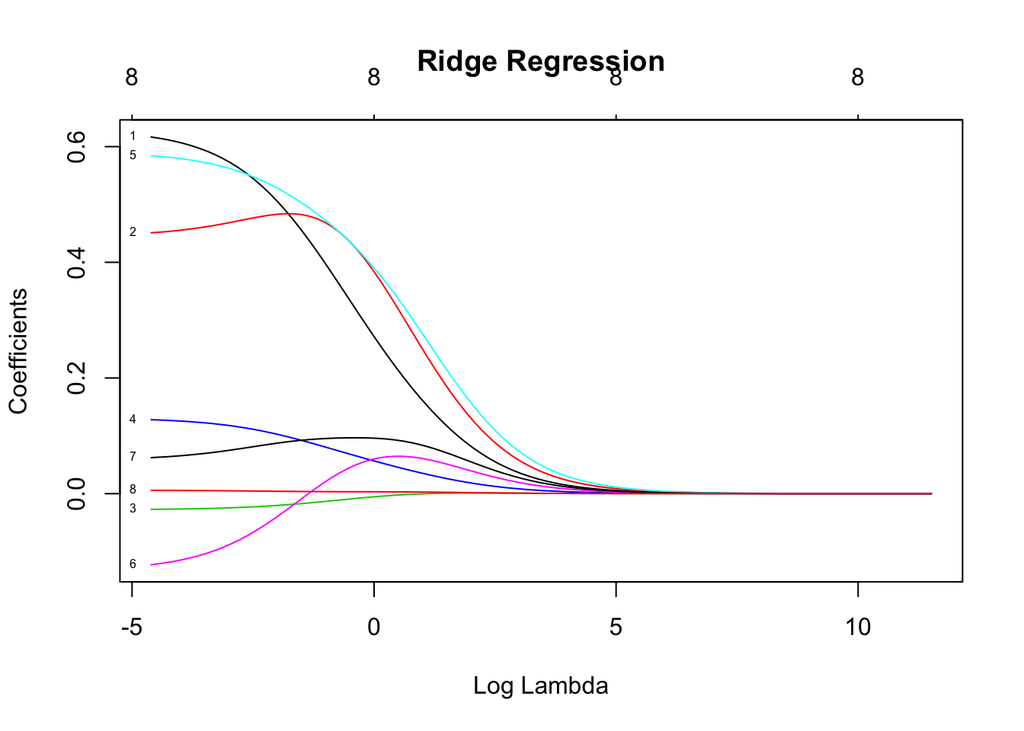

```r
plot(prost.ridge, xvar = "lambda", label = TRUE, main = "Ridge Regression")
```

Coefficients approach zero around lambda ~ 6.

#### 4. Perform 10-fold cross-validation on your training data and save the output as an object. Once a gain, use set.seed(0). (NB: You can manually define the values of lambda to as you did in part 2).

```r
set.seed(0)
prost.ridge.cv = cv.glmnet(prost.x, prost.y, alpha = 0, nfolds = 10)
```

#### 5. Create and interpret a plot associated with the 10-fold cross-validation completed in part 4.

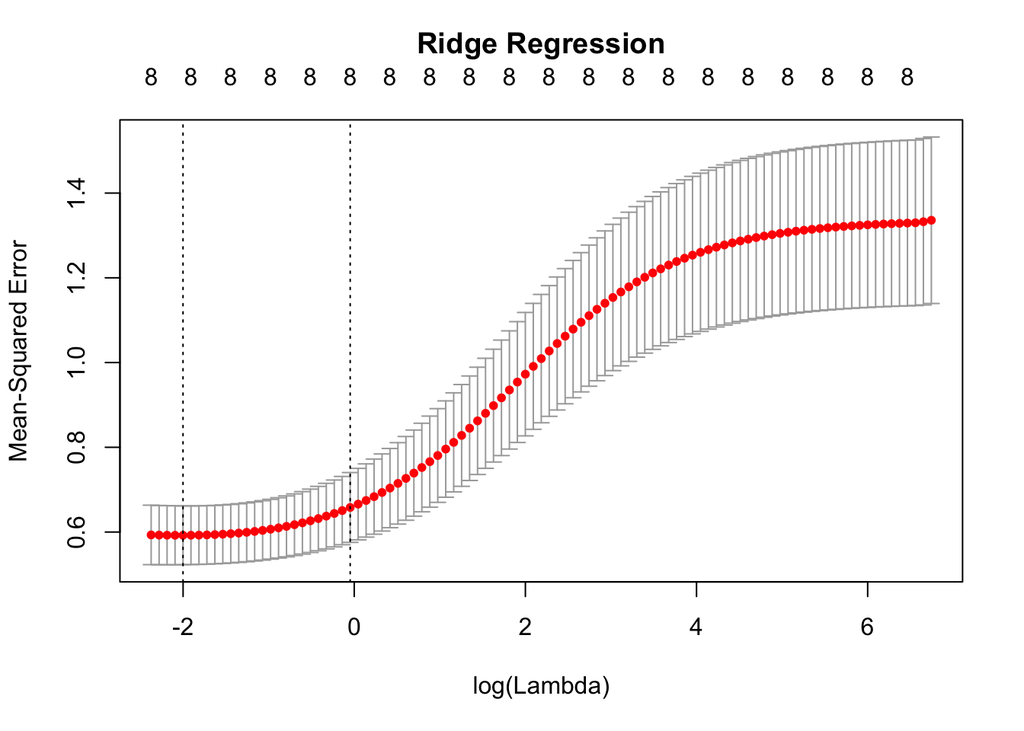

```r
plot(prost.ridge.cv, main = "Ridge Regression\n")
```

The log(Lambda) with the lowest MSE is ~ -2

#### 6. What is the best lambda?

```r
bestlambda.ridge = prost.ridge.cv$lambda.min
bestlambda.ridge
```

```
## [1] 0.1352036
```

```r
log(bestlambda.ridge)
```

```
## [1] -2.000974
```

The best lambda is .1352 ~ e^-2

#### 7. What is the test MSE associated with this lambda value?

```r
prost.ridge.best = predict(prost.ridge, s = bestlambda.ridge, newx = as.matrix(prost.test))
mean((prost.ridge.best - prost[test, 9])^2)
```

```
## [1] 0.49133
```

The test MSE associated with the best lambda value is .4913

#### 8. Refit the ridge regression using the best lambda using every observation in your original dataset. Briefly comment on the coefficient estimates.

```r
prost.all.x = model.matrix(lpsa ~ ., prost)[,-1]
prost.all.y = prost[,9]

prost.ridge.all = glmnet(prost.all.x, prost[,9], alpha = 0)
predict(prost.ridge.all, type = "coefficients", s = bestlambda.ridge)
```

```
## 9 x 1 sparse Matrix of class "dgCMatrix"
##                        1
## (Intercept) -0.037803770
## lcavol       0.460718596
## lweight      0.591231519
## age         -0.014702053
## lbph         0.081025999
## svi          0.653777586
## lcp         -0.014677049
## gleason      0.068057684
## pgg45        0.003107431
```

The coefficients are small (all less than one), svi and lweight have the highest influence on prostate cancer.

#### 9. What is the overall MSE for the model you fit in part 8? How does this compare to the MSE you found in part 7?

```r
prost.ridge.all.pred = predict(prost.ridge.all, s = bestlambda.ridge, newx = prost.all.x)
mean((prost.ridge.all.pred - prost[,9])^2)
```

```
## [1] 0.4549722
```

The overall MSE for the model is .45497, less than the model from part 7, which makes sense given that we used more observations.

### Question #3: Lasso Regression

Continue using the 08prostate.txt dataset you already loaded into your workspace. ####1. Repeat the entire analysis performed in question #2, except use the method of lasso regression instead. ####1.2. Fit a slew of lasso regression models on your training data by checking across a wide range of lambda values. Save the coefficients of these models in an object.

```r
prost.x <- model.matrix(lpsa ~ ., prost.train)[,-1]
prost.y <- prost.train$lpsa

grid <- 10^seq(5, -2, length = 100)

prost.lasso <- glmnet(prost.x, prost.y, alpha = 1, lambda = grid)

dim(coef(prost.lasso))
```

```
## [1]   9 100
```

```r
prost.lasso.coef <- coef(prost.lasso)
```

#### 1.3. Plot the coefficients of these models and comment on the shrinkage.

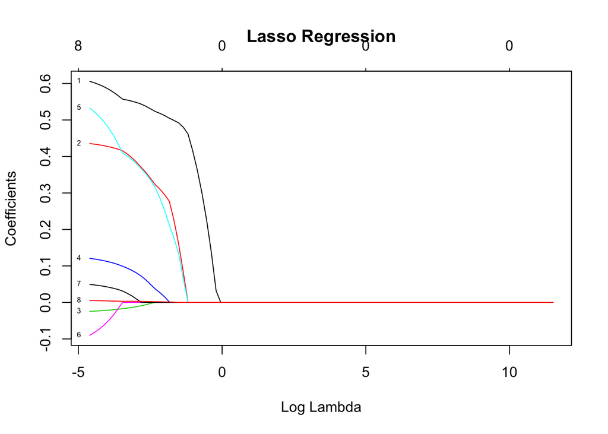

```r
plot(prost.lasso, xvar = "lambda", label = TRUE, main = "Lasso Regression")
```

#### 4. Perform 10-fold cross-validation on your training data and save the output as an object. Once a gain, use set.seed(0). (NB: You can manually define the values of lambda to as you did in part 2).

```r
set.seed(0)
prost.lasso.cv = cv.glmnet(prost.x, prost.y, alpha = 1, nfolds = 10)
```

#### 5. Create and interpret a plot associated with the 10-fold cross-validation completed in part 4.

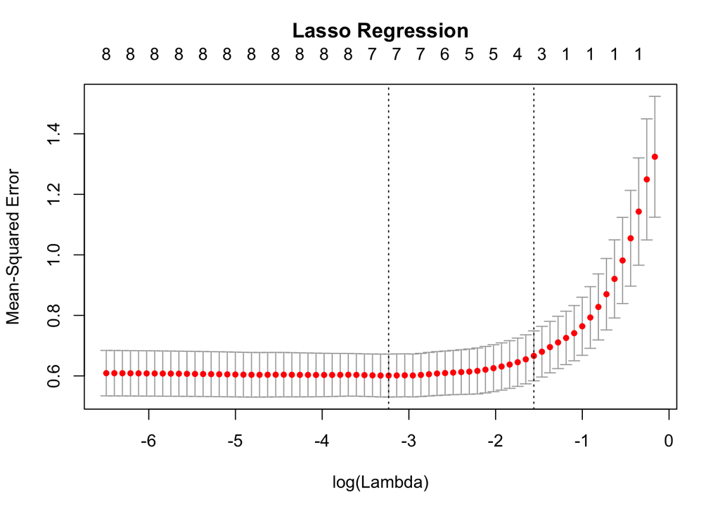

```r
plot(prost.lasso.cv, main = "Lasso Regression\n")
```

The log(Lambda) with the lowest MSE is ~ -3.2

#### 6. What is the best lambda?

```r
bestlambda.lasso = prost.lasso.cv$lambda.min
bestlambda.lasso
```

```
## [1] 0.03941255
```

```r
log(bestlambda.lasso)
```

```
## [1] -3.233671
```

The best lambda is .0394 ~ e^-3.2

#### 7. What is the test MSE associated with this lambda value?

```r
prost.lasso.best = predict(prost.lasso, s = bestlambda.lasso, newx = as.matrix(prost.test))
mean((prost.lasso.best - prost[test, 9])^2)
```

```
## [1] 0.5053537
```

The test MSE associated with the best lambda value is .5053

#### 8. Refit the ridge regression using the best lambda using every observation in your original dataset. Briefly comment on the coefficient estimates.

```r
prost.all.x = model.matrix(lpsa ~ ., prost)[,-1]
prost.all.y = prost[,9]

prost.lasso.all = glmnet(prost.all.x, prost[,9], alpha = 1)
predict(prost.lasso.all, type = "coefficients", s = bestlambda.lasso)
```

```
## 9 x 1 sparse Matrix of class "dgCMatrix"
##                        1
## (Intercept)  0.121498798
## lcavol       0.505523919
## lweight      0.538217190
## age         -0.007281578
## lbph         0.058294107
## svi          0.585188387
## lcp          .
## gleason      .
## pgg45        0.002205420
```

The coefficients are small (all less than one), svi, lweight and lcavol have the highest influence on prostate cancer. Coefficients for lcp and gleason are 0.

#### 9. What is the overall MSE for the model you fit in part 8? How does this compare to the MSE you found in part 7?

```r
prost.lasso.all.pred = predict(prost.lasso.all, s = bestlambda.lasso, newx = prost.all.x)
mean((prost.lasso.all.pred - prost[,9])^2)
```

```
## [1] 0.4612519
```

The overall MSE for the model is .46125, less than the model from part 7, which makes sense given that we used more observations.

#### 2. Compare and contrast your ultimate ridge and lasso models. Which would you choose to use? Why?

The overall and test MSEs for both models are similar enough, I would choose the lasso model because it allows for feature selection and with best lambda removes both lcp and gleason.

### Question #4: K-Means

Read in the 08protein.txt dataset into your workspace. This dataset contains protein consumption information from 1973 on nine different food groups across 25 different European countries. ####1. Use the following commands to read the data into your workspace appropriately and scale the variables: protein = read.table(“08protein.txt”, sep = ‘t’, header = TRUE) protein.scaled = as.data.frame(scale(protein[, 1])) rownames(protein.scaled) = protein$Country

```r
protein = read.table("08protein.txt", sep = '\t', header = TRUE)
protein.scaled = as.data.frame(scale(protein[, -1]))
rownames(protein.scaled) = protein$Country
```

#### 2. Create and interpret a scree-plot for the within-cluster variance for various values of K used in the K-means algorithm.

1. Why might this graph indicate that K-means is not truly appropriate to model the data?

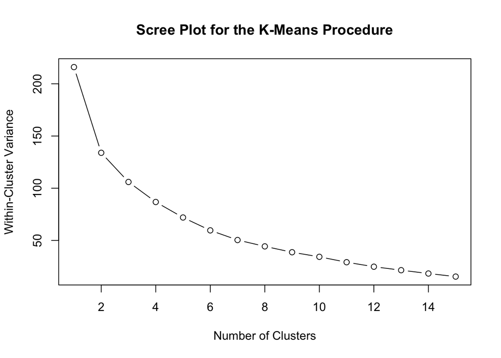

```r
wssplot = function(data, nc = 15, seed = 0) {
  wss = (nrow(data) - 1) * sum(apply(data, 2, var))
  for (i in 2:nc) {
    set.seed(seed)
    wss[i] = sum(kmeans(data, centers = i, iter.max = 100, nstart = 100)$withinss)
  }
  plot(1:nc, wss, type = "b",
       xlab = "Number of Clusters",
       ylab = "Within-Cluster Variance",
       main = "Scree Plot for the K-Means Procedure")
}
wssplot(protein.scaled)
```

The scree plot shows a smooth curve which means that each additional cluster does little to reduce marginal within cluster variance. This could mean that k means clustering is not the best method for this dataset.

#### 3. Create and store 5 different K-means solutions that run the algorithm only 1 time each. (N B: Use set.seed(0) so your results will be reproducible.)

```r
set.seed(0)
km.p1 = kmeans(protein.scaled, centers = 3)
km.p2 = kmeans(protein.scaled, centers = 3)
km.p3 = kmeans(protein.scaled, centers = 3)
km.p4 = kmeans(protein.scaled, centers = 3)
km.p5 = kmeans(protein.scaled, centers = 3)
```

#### 4. Create and store 1 K-means solution that was selected from running the algorithm 100 separate times. (N B: Use set.seed(0) so your results will be reproducible.)

```r
set.seed(0)
km.p = kmeans(protein.scaled, centers = 3, nstart = 100)
```

#### 5. Plot the 6 different solutions from part 3 and 4 with:

1. Cereals on the x-axis.
2. RedMeat on the y-axis.
3. Colors for the different cluster assignments.
4. Labels for the total within-cluster variances.

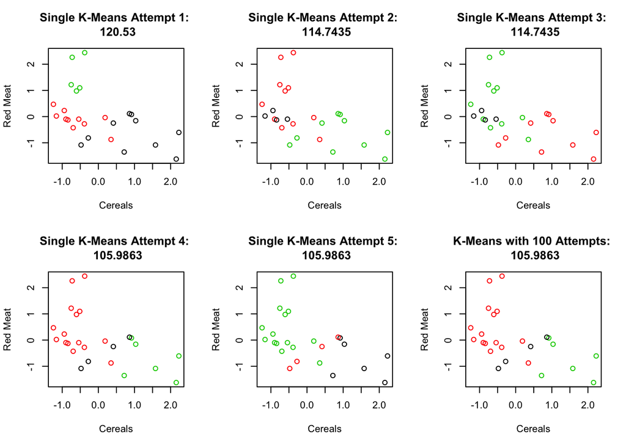

```r
par(mfrow = c(2, 3))
plot(protein.scaled$Cereals, protein.scaled$RedMeat, col = km.p1$cluster,
     xlab = "Cereals", ylab = "Red Meat",
     main = paste("Single K-Means Attempt 1: \n", round(km.p1$tot.withinss, 4)))
plot(protein.scaled$Cereals, protein.scaled$RedMeat, col = km.p2$cluster,
     xlab = "Cereals", ylab = "Red Meat",
     main = paste("Single K-Means Attempt 2: \n", round(km.p2$tot.withinss, 4)))
plot(protein.scaled$Cereals, protein.scaled$RedMeat, col = km.p3$cluster,
     xlab = "Cereals", ylab = "Red Meat",
     main = paste("Single K-Means Attempt 3: \n", round(km.p3$tot.withinss, 4)))
plot(protein.scaled$Cereals, protein.scaled$RedMeat, col = km.p4$cluster,
     xlab = "Cereals", ylab = "Red Meat",
     main = paste("Single K-Means Attempt 4: \n", round(km.p4$tot.withinss, 4)))
plot(protein.scaled$Cereals, protein.scaled$RedMeat, col = km.p5$cluster,
     xlab = "Cereals", ylab = "Red Meat",
     main = paste("Single K-Means Attempt 5: \n", round(km.p5$tot.withinss, 4)))
plot(protein.scaled$Cereals, protein.scaled$RedMeat, col = km.p$cluster,
     xlab = "Cereals", ylab = "Red Meat",
     main = paste("K-Means with 100 Attempts: \n", round(km.p$tot.withinss, 4)))
```

####6. Plot the solution from part 4 with: a. Cereals on the x-axis. b. RedMeat on the y-axis. c. A label for the total within-cluster variance. d. Points for the centroids of each cluster. e. A horizontal line at 0. f. A vertical line at 0. g. Text listing the country for each observation in your dataset (instead of points), colored by the different cluster assignments. H int: Use type = “n”when creating the plot(). Then, use the text()function in tandem with the rownames() function.

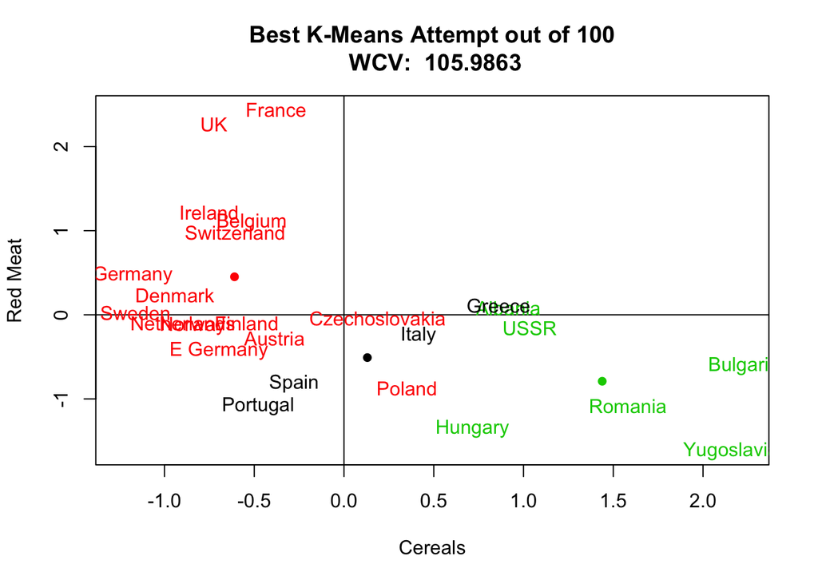

```r
par(mfrow = c(1,1))
plot(protein.scaled$Cereals, protein.scaled$RedMeat, col = km.p$cluster,
     xlab = "Cereals", ylab = "Red Meat", type = "n",
     main = paste("Best K-Means Attempt out of 100\n WCV: ", round(km.p$tot.withinss, 4)))
points(km.p$centers[, 6], km.p$centers[, 1], pch = 16, col = c(1:3))
abline(h=0)
abline(v=0)
text(protein.scaled$Cereals, protein.scaled$RedMeat, labels=row.names(protein.scaled), col = km.p$cluster)
```